# Reproducible Research: Peer Assessment 1

## Loading and preprocessing the data

1. Loading Data

```r
# Loading libraries
library(data.table)
library(dplyr)
library(ggplot2)
library(lubridate)
library(plyr)

# Loading data
df <- fread("activity.csv")
head(df)
```

```
##    steps       date interval
## 1:    NA 2012-10-01        0
## 2:    NA 2012-10-01        5
## 3:    NA 2012-10-01       10
## 4:    NA 2012-10-01       15
## 5:    NA 2012-10-01       20
## 6:    NA 2012-10-01       25
```

2. **Preprocessing data**: a new variable “timeInterval” is created, containing the conversion of the variable “interval” from integer to POSIXct although this had no use for us later.

```r
to_time <- function(x){
    # returns the 5-minutes interval in "hh:nn" format.
    sprintf("%02d:%02d", x%/%100, x%%100)
}
df$timeInterval <- with(df, as.POSIXct(paste(date, to_time(interval)), format="%Y-%m-%d %H:%M"))
head(df)
```

```
##    steps       date interval        timeInterval
## 1:    NA 2012-10-01        0 2012-10-01 00:00:00
## 2:    NA 2012-10-01        5 2012-10-01 00:05:00
## 3:    NA 2012-10-01       10 2012-10-01 00:10:00
## 4:    NA 2012-10-01       15 2012-10-01 00:15:00
## 5:    NA 2012-10-01       20 2012-10-01 00:20:00
## 6:    NA 2012-10-01       25 2012-10-01 00:25:00
```

## What is mean total number of steps taken per day?

1. Calculating the total number of steps taken each day

```r
totalStepsPerDay <- df %>% dplyr::group_by(date) %>% dplyr::summarise(totalSteps = sum(steps, na.rm = TRUE))
head(totalStepsPerDay)
```

```
## # A tibble: 6 x 2
##   date       totalSteps
##   <date>          <int>
## 1 2012-10-01          0
## 2 2012-10-02        126
## 3 2012-10-03      11352
## 4 2012-10-04      12116
## 5 2012-10-05      13294
## 6 2012-10-06      15420
```

2. Histogram of the total number of steps taken each day

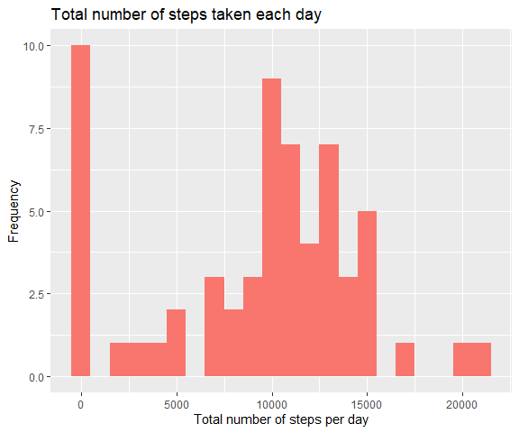

```r
qplot(totalStepsPerDay$totalSteps, binwidth = 1000, xlab = "Total number of steps per day", ylab = "Frequency", main = "Total number of steps taken each day", fill = "red") + guides(fill = FALSE)
```

3. Calculating the mean and median of the total number of steps taken per day

```r
meanTotalStepsPerDay <- mean(totalStepsPerDay$totalSteps, na.rm = TRUE)
medianTotalStepsPerDay <- median(totalStepsPerDay$totalSteps, na.rm = TRUE)
```

- The mean of the total number of steps taken per day is: **9354.2295082**
- The median of the total number of steps taken per day is: **10395**

## What is the average daily activity pattern?

1. The average number of steps taken across all days

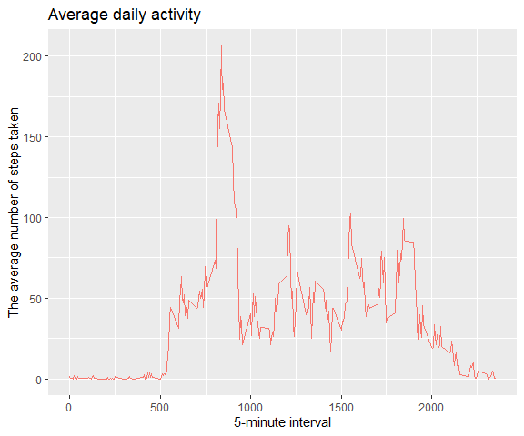

```r
dailyAverage <- df %>% dplyr::group_by(interval) %>% dplyr::summarise(dailyAverageSteps = mean(steps, na.rm = TRUE))
# plotting
qplot(interval, dailyAverageSteps, data = dailyAverage, geom = "line", col = "red", xlab = "5-minute interval", ylab = "The average number of steps taken", main = "Average daily activity") + guides(col = FALSE)
```

2. The 5-minute interval containing the maximum number of steps

```r
maxInterval <- dailyAverage %>% filter(dailyAverageSteps == max(dailyAverageSteps))
```

- The 5-minute interval containing the maximum number of steps is **08:35**

## Imputing missing values

1. Calculating the total number of missing values in the dataset

```r
nbrNA <- sum(!complete.cases(df))
```

- The total number of missing values is: **2304**
2. Missing values can be treated using several methods such as **mean/mode/median** imputation, **KNN** imputation or using a **prediction model** to estimate values that will substitute the missing data.  
   In the following an implementation of an imputation method based on the mean.

```r
imputeByMean <- function(x) replace(x, is.na(x), mean(x, na.rm = TRUE))
```

3. Creation of a new dataset with the missing data filled in by the mean for 5-minute interval.

```r
# Apply mean imputation after grouping data by interval
df2 <- df %>% dplyr::group_by(interval) %>% dplyr::mutate(steps = imputeByMean(steps))
head(df2)
```

```
## # A tibble: 6 x 4
## # Groups:   interval [6]
##    steps date       interval timeInterval
##    <dbl> <date>        <int> <dttm>
## 1 1.72   2012-10-01        0 2012-10-01 00:00:00
## 2 0.340  2012-10-01        5 2012-10-01 00:05:00
## 3 0.132  2012-10-01       10 2012-10-01 00:10:00
## 4 0.151  2012-10-01       15 2012-10-01 00:15:00
## 5 0.0755 2012-10-01       20 2012-10-01 00:20:00
## 6 2.09   2012-10-01       25 2012-10-01 00:25:00
```

4. Histogram of the total number of steps taken each day

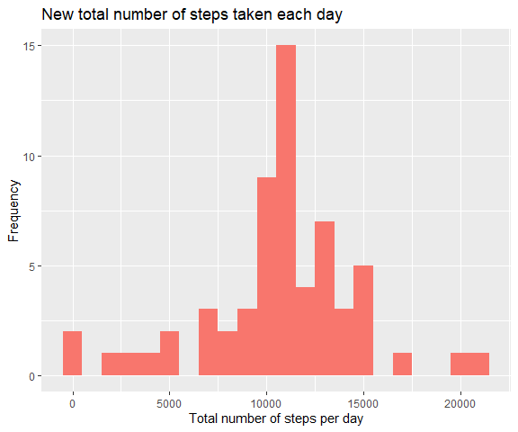

```r
totalStepsPerDay2 <- df2 %>% dplyr::group_by(date) %>% dplyr::summarise(totalSteps = sum(steps, na.rm = TRUE))
# histogram
qplot(totalStepsPerDay2$totalSteps, binwidth = 1000, xlab = "Total number of steps per day", ylab = "Frequency", main = "New total number of steps taken each day", fill = "red") + guides(fill = FALSE)
```

```r
# Mean & Median
meanTotalStepsPerDay2 <- mean(totalStepsPerDay2$totalSteps)
medianTotalStepsPerDay2 <- median(totalStepsPerDay2$totalSteps)
```

- The new mean of the total number of steps taken per day is: **1.076618910^{4}**
- The new median of the total number of steps taken per day is: **1.076618910^{4}**
- The new values of the mean, as well as the median, are visibly larger. This is because many of the null values have been replaced with the 5-minute interval averages after applying the imputation.

## Are there differences in activity patterns between weekdays and weekends?

1. Create a new factor variable indicating whether a given date is a weekday or weekend day.

```r
df2 <- df2 %>% dplyr::mutate(weekDay = factor(1*(weekdays(date) %in% c("Saturday", "Sunday")), labels = c("weekday", "weekend") ))
head(df2)
```

```
## # A tibble: 6 x 5
## # Groups:   interval [6]
##    steps date       interval timeInterval        weekDay
##    <dbl> <date>        <int> <dttm>              <fct>
## 1 1.72   2012-10-01        0 2012-10-01 00:00:00 weekday
## 2 0.340  2012-10-01        5 2012-10-01 00:05:00 weekday
## 3 0.132  2012-10-01       10 2012-10-01 00:10:00 weekday
## 4 0.151  2012-10-01       15 2012-10-01 00:15:00 weekday
## 5 0.0755 2012-10-01       20 2012-10-01 00:20:00 weekday
## 6 2.09   2012-10-01       25 2012-10-01 00:25:00 weekday
```

2. The average number of steps taken across all weekday days or weekend days

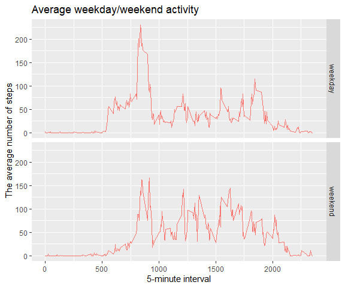

```r
weekdayAverage <- df2 %>% dplyr::group_by(interval, weekDay) %>% dplyr::summarise(weekdayAverageSteps = mean(steps, na.rm = TRUE))
# plotting
qplot(interval, weekdayAverageSteps, data = weekdayAverage, geom = "line", col = "red", facets = weekDay ~ ., xlab = "5-minute interval", ylab = "The average number of steps", main = "Average weekday/weekend activity") + guides(col = FALSE)
```